# Practica03

Christian Meza, Carlos Alama y Rony Orocollo

2024-05-25

# Actividad Evaluable 3

## Análisis de logs de servidor usando R (parte II)

Se procede a cargar las librerías

```r
#install.packages("httr")
#install.packages("XML")
#install.packages("stringr")
#install.packages("readr")
#install.packages("dplyr")
#install.packages("ggplot2")
library(httr)
library(XML)
library(dplyr)
library(stringr)
library(readr)
library(ggplot2)
```

### 2. Incluid en el documento un apartado con la descripción de los datos analizados: fuente, tipología, descripción de la información contenida (los diferentes campos) y sus valores.

A continuación se detalla el significado de las columnas del data frame “epa_http”:

- Request
- timestamp
- petition
- URL
- protocol
- response_code
- bytes_reply

200 Correcto acceso 302 Ha sido modivo temporalmente 304 Recurso no ha sido modificado desde último acceso 400 No procesa solicitud por error de cliente 403 Acceso a página esta restringido 404 La URL ingresada no esta disponible 500 Error interno de servidor 501 Servidor no responde solicitud de cliente

### 3. Aprovechando que los datos a analizar son los mismos de la primera práctica, para esta entrega es imprescindible que los datos estén en formato de “datos elegantes”.

Para un mejor entendimiento de la informaciòn, se procede a cambiar los nombres de las cabeceras del dataSet epa_http a “Request”, “timestamp”, “petition”, “URL”, “protocol”, “response_code” y “bytes_reply”

```r
names(epa_http) <- c("Request", "timestamp", "petition", "URL", "protocol", "response_code", "bytes_reply")
epa_http
```

```
## # A tibble: 47,748 × 7
##    Request           timestamp petition URL   protocol response_code bytes_reply
##    <chr>             <chr>     <chr>    <chr> <chr>            <dbl> <chr>
##  1 141.243.1.172     [29:23:5… "\"GET"  /Sof… "HTTP/1…           200 1497
##  2 query2.lycos.cs.… [29:23:5… "\"GET"  /Con… "HTTP/1…           200 1325
##  3 tanuki.twics.com  [29:23:5… "\"GET"  /New… "HTTP/1…           200 1014
##  4 wpbfl2-45.gate.n… [29:23:5… "\"GET"  /     "HTTP/1…           200 4889
##  5 wpbfl2-45.gate.n… [29:23:5… "\"GET"  /ico… "HTTP/1…           200 2624
##  6 wpbfl2-45.gate.n… [29:23:5… "\"GET"  /log… "HTTP/1…           200 935
##  7 140.112.68.165    [29:23:5… "\"GET"  /log… "HTTP/1…           200 2788
##  8 wpbfl2-45.gate.n… [29:23:5… "\"GET"  /log… "HTTP/1…           200 124
##  9 wpbfl2-45.gate.n… [29:23:5… "\"GET"  /ico… "HTTP/1…           200 156
## 10 wpbfl2-45.gate.n… [29:23:5… "\"GET"  /log… "HTTP/1…           200 2788
## # ℹ 47,738 more rows
```

Tras el anàlisis de la informaciòn, se ha encontrado data vacìa y con el signo “-”. se renombra y se cambia a null a continuaciòn:

```r
epa_http[is.na(epa_http)] <- "null"
epa_http[epa_http == "-"] <- "null"
epa_http
```

```
## # A tibble: 47,748 × 7
##    Request           timestamp petition URL   protocol response_code bytes_reply
##    <chr>             <chr>     <chr>    <chr> <chr>            <dbl> <chr>
##  1 141.243.1.172     [29:23:5… "\"GET"  /Sof… "HTTP/1…           200 1497
##  2 query2.lycos.cs.… [29:23:5… "\"GET"  /Con… "HTTP/1…           200 1325
##  3 tanuki.twics.com  [29:23:5… "\"GET"  /New… "HTTP/1…           200 1014
##  4 wpbfl2-45.gate.n… [29:23:5… "\"GET"  /     "HTTP/1…           200 4889
##  5 wpbfl2-45.gate.n… [29:23:5… "\"GET"  /ico… "HTTP/1…           200 2624
##  6 wpbfl2-45.gate.n… [29:23:5… "\"GET"  /log… "HTTP/1…           200 935
##  7 140.112.68.165    [29:23:5… "\"GET"  /log… "HTTP/1…           200 2788
##  8 wpbfl2-45.gate.n… [29:23:5… "\"GET"  /log… "HTTP/1…           200 124
##  9 wpbfl2-45.gate.n… [29:23:5… "\"GET"  /ico… "HTTP/1…           200 156
## 10 wpbfl2-45.gate.n… [29:23:5… "\"GET"  /log… "HTTP/1…           200 2788
## # ℹ 47,738 more rows
```

Se procede a quitar el signo comillas que inicia y termina en los valores de las columnas “petition” y “protocol”

```r
# Usar mutate() de dplyr junto con gsub()
epa_http <- epa_http %>%
  mutate(
    petition = gsub('"', '', petition),
    protocol = gsub('"', '', protocol))
```

Se procede convertir la columna ‘timestamp’ a formato de fecha y hora:

```r
epa_http$timestamp <- as.POSIXct(epa_http$timestamp, format = "[%d:%H:%M:%S]")
epa_http
```

```
## # A tibble: 47,748 × 7
##    Request timestamp           petition URL   protocol response_code bytes_reply
##    <chr>   <dttm>              <chr>    <chr> <chr>            <dbl> <chr>
##  1 141.24… 2024-05-29 23:53:25 GET      /Sof… HTTP/1.0           200 1497
##  2 query2… 2024-05-29 23:53:36 GET      /Con… HTTP/1.0           200 1325
##  3 tanuki… 2024-05-29 23:53:53 GET      /New… HTTP/1.0           200 1014
##  4 wpbfl2… 2024-05-29 23:54:15 GET      /     HTTP/1.0           200 4889
##  5 wpbfl2… 2024-05-29 23:54:16 GET      /ico… HTTP/1.0           200 2624
##  6 wpbfl2… 2024-05-29 23:54:18 GET      /log… HTTP/1.0           200 935
##  7 140.11… 2024-05-29 23:54:19 GET      /log… HTTP/1.0           200 2788
##  8 wpbfl2… 2024-05-29 23:54:19 GET      /log… HTTP/1.0           200 124
##  9 wpbfl2… 2024-05-29 23:54:19 GET      /ico… HTTP/1.0           200 156
## 10 wpbfl2… 2024-05-29 23:54:19 GET      /log… HTTP/1.0           200 2788
## # ℹ 47,738 more rows
```

### 4. Identificar el número único de usuarios que han interactuado directamente con el servidor de forma segregada según si los usuarios han tenido algún tipo de error en las distintas peticiones ofrecidas por el servidor.

```r
# Filtrar interacciones que han encontrado errores
interactions_with_errors <- epa_http %>%
  filter(response_code >= 400 & response_code < 600)

# Identificar URLs únicas con errores
unique_urls_with_errors <- distinct(interactions_with_errors, URL)

# Filtrar interacciones que no han encontrado errores
interactions_without_errors <- epa_http %>%
  filter(response_code < 400)

# Identificar URLs únicas sin errores
unique_urls_without_errors <- distinct(interactions_without_errors, URL)

# Contar el número de usuarios por URLs únicas que han encontrado errores
num_urls_with_errors <- nrow(unique_urls_with_errors)

# Contar el número de usuarios por URLs únicas que no han encontrado errores
num_urls_without_errors <- nrow(unique_urls_without_errors)


# Identificar los distintos tipos de errores
error_types <- unique(epa_http$response_code[epa_http$response_code >= 400 & epa_http$response_code < 600])

# Filtrar los errores y contar el número de interacciones únicas por tipo de error
error_summary <- epa_http %>%
  filter(response_code >= 400 & response_code < 600) %>%
  group_by(response_code) %>%
  summarise(unique_interactions = n_distinct(URL))
print(error_summary)
```

```
## # A tibble: 5 × 2
##   response_code unique_interactions
##           <dbl>               <int>
## 1           400                   6
## 2           403                  12
## 3           404                 257
## 4           500                  40
## 5           501                   8
```

Lo que se visualizo en la información anterior, filtran los errores y se cuenta el número de interacciones únicas por tipo de error.

Se identifican los distintos tipos de errores que son lo siguientes: 404, 403, 501, 500, 400

### 5. Analizar los distintos tipos de peticiones HTTP (GET, POST, PUT, DELETE) gestionadas por el servidor, identificando la frecuencia de cada una de estas. Repetir el análisis, esta vez filtrando previamente aquellas peticiones correspondientes a recursos ofrecidos de tipo imagen.

```r
# Contar la frecuencia de cada tipo de petición HTTP
petition_summary <- epa_http %>%
  group_by(petition) %>%
  summarise(frequency = n())

print(petition_summary)
```

```
## # A tibble: 3 × 2
##   petition frequency
##   <chr>        <int>
## 1 GET          46020
## 2 HEAD           106
## 3 POST          1622
```

```r
# Filtrar peticiones a recursos de tipo imagen
image_requests <- epa_http %>%
  filter(grepl("\\.(gif|jpg|jpeg|png)$", URL, ignore.case = TRUE))

# Contar la frecuencia de cada tipo de petición HTTP para recursos de tipo imagen
image_petition_summary <- image_requests %>%
  group_by(petition) %>%
  summarise(frequency = n())

print(image_petition_summary)
```

```
## # A tibble: 3 × 2
##   petition frequency
##   <chr>        <int>
## 1 GET          22179
## 2 HEAD            56
## 3 POST           206
```

### 6. Generar al menos 2 gráficos distintos que permitan visualizar alguna característica relevante de los datos analizados.

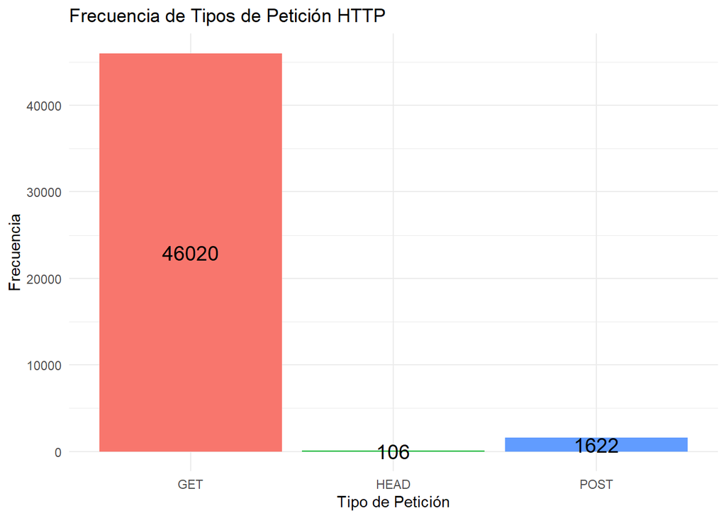

```r
# Contar la frecuencia de cada tipo de petición HTTP
petition_summary <- epa_http %>%
  group_by(petition) %>%
  summarise(frequency = n())

# Filtrar peticiones a recursos de tipo imagen
image_requests <- epa_http %>%
  filter(grepl("\\.(gif|jpg|jpeg|png)$", URL, ignore.case = TRUE))

# Contar la frecuencia de cada tipo de petición HTTP para recursos de tipo imagen
image_petition_summary <- image_requests %>%
  group_by(petition) %>%
  summarise(frequency = n())



# Crear el gráfico de barras
ggplot(petition_summary, aes(x = petition, y = frequency, fill = petition)) +
  geom_bar(stat = "identity") +
  geom_text(aes(label = frequency), position = position_stack(vjust = 0.5), color = "black", size = 5) +
  # Colocar las cantidades encima de las barras
  labs(title = "Frecuencia de Tipos de Petición HTTP", x = "Tipo de Petición", y = "Frecuencia") +
  theme_minimal() +
  theme(legend.position = "none")
```

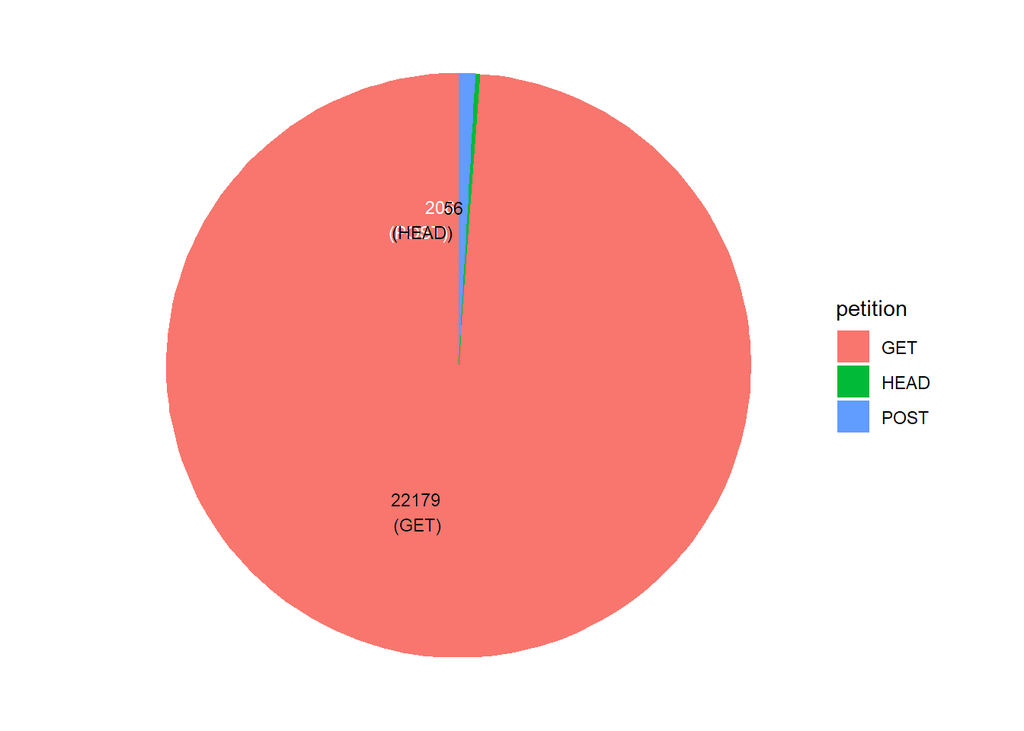

```r
# Crear el gráfico de pastel con etiquetas fuera del círculo
ggplot(image_petition_summary, aes(x = "", y = frequency, fill = petition)) +
  geom_bar(width = 1, stat = "identity") +
  coord_polar("y") +
  geom_text(aes(label = paste0(frequency, "\n(", petition, ")")),
            position = position_stack(vjust = 0.5), color = "white", size = 3,
            angle = 0, hjust = 1.25) + # Colocar las cantidades fuera del círculo del pastel
  geom_text(aes(label = paste0(frequency, "\n(", petition, ")")),
            position = position_stack(vjust = 0.5), color = "black", size = 3,
            angle = 0, hjust = 1.25, check_overlap = TRUE) + # Dispersar las etiquetas y evitar superposiciones
  theme_void() +
  theme(legend.position = "right")
```

### 7. Generar un gráfico que permita visualizar el número de peticiones servidas a lo largo del tiempo.

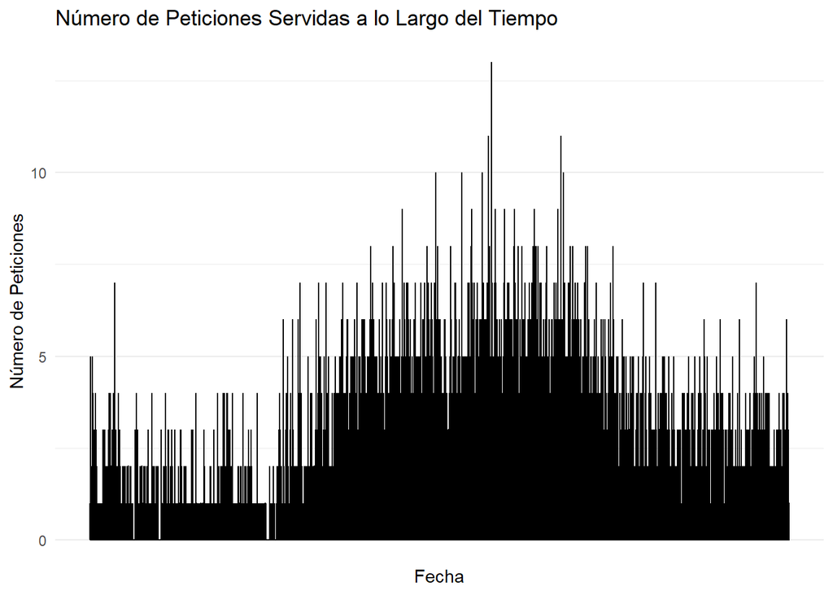

```r
# Crear un gráfico de líneas que muestre el número de peticiones servidas a lo largo del tiempo
ggplot(epa_http, aes(x = timestamp)) +
  geom_histogram(binwidth = 1, fill = "blue", color = "black") +
  scale_x_datetime(date_labels = "%Y-%m", date_breaks = "1 month") +
  labs(title = "Número de Peticiones Servidas a lo Largo del Tiempo", x = "Fecha", y = "Número de Peticiones") +
  theme_minimal()
```